# **Navires 2023 à la mano**

## Auteurs

### Majeure IMAGE

- David CHEMALY
  - login: david.chemaly
- Raphaël DUHEN
  - login: raphael.duhen

# **Projet IREN - Promotion 2024**

## Import des données

```python
import os
import numpy as np
import pandas as pd
import seaborn as sns
import tensorflow as tf
from matplotlib import pyplot as plt
```

```python
%matplotlib inline
```

```python
input_path = '/kaggle/input/navires-2023-la-mano/ships16x24/ships_16x24_10cat/data'
```

```python
SEED = 123
np.random.seed(SEED)
tf.random.set_seed(SEED)
```

```python
!tar xzf /kaggle/input/navires-2023-la-mano/ships.tgz
```

```
tar (child): /kaggle/input/navires-2023-la-mano/ships.tgz: Cannot open: No such file or directory
tar (child): Error is not recoverable: exiting now
tar: Child returned status 2
tar: Error is not recoverable: exiting now
```

```python
!ls /kaggle/working
```

```
__notebook__.ipynb
```

## Paramètres

```python
img_height = 16
img_width = 24
batch_size = 32
validation_split = 0.1
```

## Lecture des images

Le code utilise la classe ImageDataGenerator de Keras pour générer des lots d'images augmentées à partir d'un répertoire contenant des données d'images pour la classification de bateaux. Voici un résumé de ce que le code fait :

Il crée une instance de ImageDataGenerator avec quelques options de transformation d'images :

- **horizontal_flip=True** : permet de réaliser des retournements horizontaux aléatoires des images pendant l'augmentation des données, ce qui peut aider à améliorer la robustesse du modèle.
- **rescale=1./255** : réduit les valeurs de pixels des images à l'intervalle [0, 1] en les divisant par 255.
- **validation_split=validation_split** : spécifie la proportion des données à utiliser pour la validation.

Ensuite, le générateur de données d'entraînement (training_gen) est créé en utilisant la méthode flow_from_directory :

- **input_path** : le chemin du répertoire contenant les données d'images pour l'entraînement et la validation.
- **target_size=(img_height, img_width)** : spécifie la taille souhaitée pour les images.
- **batch_size=batch_size** : définit la taille des mini-lots d'images à générer.
- **seed=SEED** : fixe la graine aléatoire pour la reproductibilité des résultats.
- **subset='training'** : indique que ce générateur est utilisé pour les données d'entraînement.
- **class_mode='categorical'** : utilise l'encodage catégoriel des étiquettes de classe.
- **color_mode='rgb'** : spécifie le mode de couleur des images en RGB.
- **shuffle=True** : mélange les images à chaque époque d'entraînement.
- **interpolation="bicubic"** : utilise l'interpolation bicubique pour redimensionner les images. L'interpolation bicubique est une méthode courante pour redimensionner les images en préservant les détails et en atténuant les artefacts.

De même, le générateur de données de validation (validation_gen) est créé en utilisant la méthode flow_from_directory. Les paramètres sont similaires à training_gen, à l'exception de subset='validation' et shuffle=False (pas de mélange des images de validation).

L'utilisation de l'interpolation bicubique pour le redimensionnement des images peut être avantageuse car elle fournit une meilleure qualité d'interpolation par rapport à d'autres méthodes plus simples, telles que l'interpolation bilinéaire. Cela peut aider à préserver les détails et les contours des bateaux dans les images redimensionnées, ce qui peut être important pour la tâche de classification.

```python
from keras.preprocessing.image import ImageDataGenerator

datagen = ImageDataGenerator(
    horizontal_flip=True,
    rescale=1./255,
    validation_split=validation_split
)

training_gen = datagen.flow_from_directory(
    input_path,
    target_size=(img_height, img_width),
    batch_size=batch_size,
    seed=SEED,
    subset='training',
    class_mode='categorical',
    color_mode='rgb',
    shuffle=True,
    interpolation="bicubic"
)

validation_gen = datagen.flow_from_directory(
    input_path,
    target_size=(img_height, img_width),
    batch_size=batch_size,
    seed=SEED,
    subset='validation',
    class_mode='categorical',
    color_mode='rgb',
    shuffle=False,
    interpolation="bicubic"
)
```

```
Found 31968 images belonging to 10 classes.
Found 3547 images belonging to 10 classes.
```

## Présentation des données

Ce code définit une fonction appelée generator_plot qui permet de visualiser les images générées par un générateur de données. La fonction affiche les images en utilisant la bibliothèque Matplotlib, avec les étiquettes correspondantes à chaque image. Les informations sur la taille du lot, la taille des images et le nombre de canaux sont également affichées. Cette fonction est utile pour vérifier et inspecter les données générées par le générateur avant de les utiliser pour l'entraînement ou l'évaluation d'un modèle de classification.

```python
def generator_plot(gen):
    labels = gen.class_indices
    batch_size = gen.batch_size

    plt.figure(figsize=(16, 14))
    image, lbs = gen.next()
    num_images = image.shape[0]
    image_size = image.shape[1:3]
    num_channels = image.shape[3]

    print(f'Batch size: {batch_size}\nImage size: {image_size[0]} x {image_size[1]}\nNumber of channels: {num_channels}')

    num_rows = (batch_size + 4) // 5
    num_cols = min(batch_size, 5)

    for i in range(num_images):
        plt.subplot(num_rows, num_cols, i + 1)
        num_class = np.argmax(lbs[i])
        class_name = list(labels.keys())[list(labels.values()).index(num_class)]
        plt.title(class_name)
        plt.imshow(image[i])

    plt.tight_layout()
    plt.show()

    gen.reset()
```

```
Batch size: 32
Image size: 16 x 24
Number of channels: 3
```

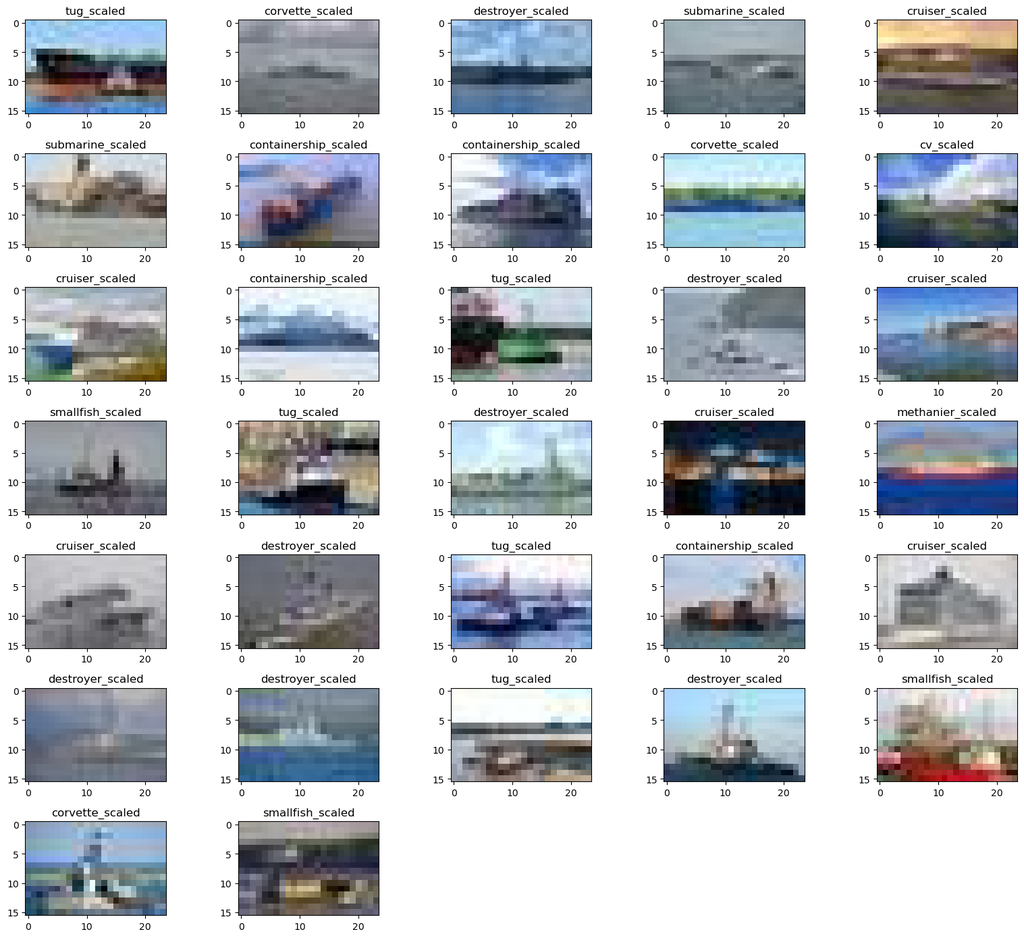

```python
generator_plot(training_gen)
```

```
Batch size: 32
Image size: 16 x 24
Number of channels: 3
```

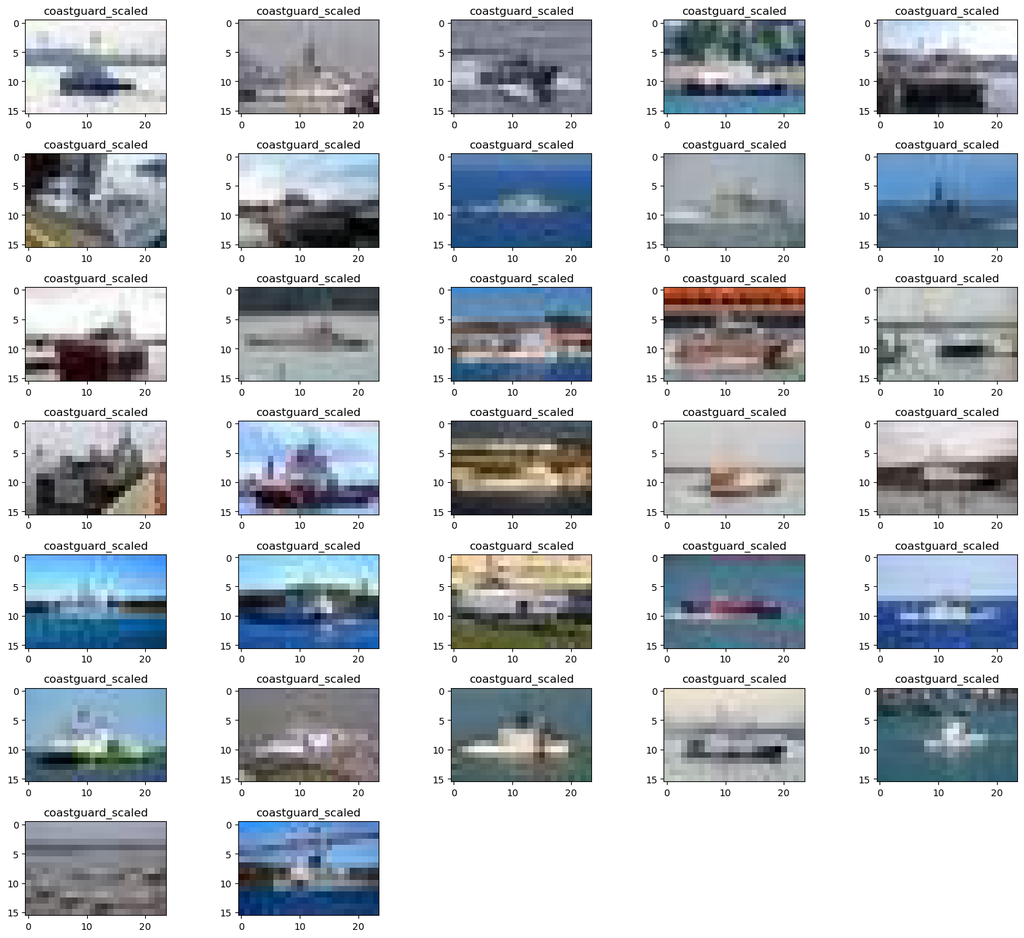

```python
generator_plot(validation_gen)
```

## Création du réseau

Le réseau de neurones convolutifs (CNN) défini dans le code est un modèle de classification d'images profond et complexe. Il est composé de plusieurs couches de convolution, de max pooling, de normalisation par lots (batch normalization) et de couches entièrement connectées (fully connected).

Le modèle commence par une couche de redimensionnement (resizing) qui adapte la taille des images d'entrée à 48x48 pixels, le nombre 48 a été choisi étant le PPCM(Plus Petit Commun Multiple) de 16 et 24. Ensuite, il enchaîne les couches de convolution avec différentes tailles de filtres pour extraire des caractéristiques à différentes échelles. Les couches de max pooling réduisent progressivement la taille spatiale des caractéristiques extraites, tout en maintenant leur pertinence.

Des techniques de régularisation, telles que le dropout, sont utilisées pour réduire le surapprentissage. La normalisation par lots (batch normalization) est appliquée après certaines couches pour stabiliser l'apprentissage du réseau.

Après les couches convolutives, le modèle se termine par des couches entièrement connectées qui effectuent la classification. Ces couches utilisent des fonctions d'activation swish, qui sont des fonctions non linéaires permettant d'introduire de la non-linéarité dans le modèle.

Finalement, le modèle est compilé avec une fonction de perte de cross-entropy catégorielle et un optimiseur Nadam, qui combine les avantages de l'algorithme Adam et de l'algorithme Nesterov Accelerated Gradient.

```python
from keras.models import Sequential
from keras.optimizers import Adam
from keras.layers import Dense, Dropout, Flatten, Conv2D, MaxPooling2D, BatchNormalization, Resizing

init_shape=(16, 24, 3)
input_shape=(48, 48, 3)

model = Sequential([
    Resizing(48, 48, interpolation="bicubic", input_shape=init_shape),

    Conv2D(128, (3,3), padding='same', activation='swish', input_shape=input_shape),
    Conv2D(128, (3,3), padding='same', activation='swish', input_shape=input_shape),
    MaxPooling2D(pool_size=(2,2)),
    Dropout(0.4),
    BatchNormalization(),

    Conv2D(256, (3,3), padding='same', activation='swish', input_shape=input_shape),
    Conv2D(256, (3,3), padding='same', activation='swish', input_shape=input_shape),
    MaxPooling2D(pool_size=(2,2)),
    Dropout(0.5),
    BatchNormalization(),

    Conv2D(512, (3,3), padding='same', activation='swish', input_shape=input_shape),
    Conv2D(512, (3,3), padding='same', activation='swish', input_shape=input_shape),
    MaxPooling2D(pool_size=(2,2)),
    Dropout(0.5),
    BatchNormalization(),

    Conv2D(768, (3,3), padding='same', activation='swish', input_shape=input_shape),
    Conv2D(768, (3,3), padding='same', activation='swish', input_shape=input_shape),
    Dropout(0.6),
    BatchNormalization(),

    Conv2D(1024, (3,3), padding='same', activation='swish', input_shape=input_shape),
    Conv2D(1024, (3,3), padding='same', activation='swish', input_shape=input_shape),
    BatchNormalization(),
    Dropout(0.6),

    Flatten(),

    Dropout(0.6),
    Dense(4000, activation='swish'),
    Dense(2000, activation='swish'),
    Dense(10, activation='softmax')
])

model.compile(loss='categorical_crossentropy',
              optimizer='Nadam',
              metrics=['accuracy'])

model.build()
```

```python
model.summary()
```

```
Model: "sequential"
_________________________________________________________________
 Layer (type)                Output Shape              Param #
=================================================================
 resizing (Resizing)         (None, 48, 48, 3)         0

 conv2d (Conv2D)             (None, 48, 48, 128)       3584

 conv2d_1 (Conv2D)           (None, 48, 48, 128)       147584

 max_pooling2d (MaxPooling2D  (None, 24, 24, 128)      0
 )

 dropout (Dropout)           (None, 24, 24, 128)       0

 batch_normalization (BatchN  (None, 24, 24, 128)      512
 ormalization)

 conv2d_2 (Conv2D)           (None, 24, 24, 256)       295168

 conv2d_3 (Conv2D)           (None, 24, 24, 256)       590080

 max_pooling2d_1 (MaxPooling  (None, 12, 12, 256)      0
 2D)

 dropout_1 (Dropout)         (None, 12, 12, 256)       0

 batch_normalization_1 (Batc  (None, 12, 12, 256)      1024
 hNormalization)

 conv2d_4 (Conv2D)           (None, 12, 12, 512)       1180160

 conv2d_5 (Conv2D)           (None, 12, 12, 512)       2359808

 max_pooling2d_2 (MaxPooling  (None, 6, 6, 512)        0
 2D)

 dropout_2 (Dropout)         (None, 6, 6, 512)         0

 batch_normalization_2 (Batc  (None, 6, 6, 512)        2048
```

[output cut: 20 more lines]

```
 flatten (Flatten)           (None, 36864)             0

 dropout_5 (Dropout)         (None, 36864)             0

 dense (Dense)               (None, 4000)              147460000

 dense_1 (Dense)             (None, 2000)              8002000

 dense_2 (Dense)             (None, 10)                20010

=================================================================
Total params: 185,435,162
Trainable params: 185,429,786
Non-trainable params: 5,376
_________________________________________________________________
```

```python
print("Nombre de couches : ", len(model.layers))
```

```
Nombre de couches :  29
```

Le rappel EarlyStopping est utilisé pour arrêter l'entraînement prématurément si une métrique de validation (dans ce cas, la précision) cesse de s'améliorer pendant un certain nombre d'époques défini par le paramètre "patience". Il permet d'éviter un surapprentissage excessif en stoppant l'entraînement lorsque la performance sur les données de validation ne s'améliore plus.

Le rappel ReduceLROnPlateau est utilisé pour réduire le taux d'apprentissage lorsque la perte sur les données de validation cesse de s'améliorer pendant un certain nombre d'époques défini par le paramètre "patience". Cela permet d'ajuster le processus d'apprentissage en réduisant progressivement le taux d'apprentissage afin d'atteindre une convergence plus précise.

```python
from keras.callbacks import EarlyStopping
from keras.callbacks import ReduceLROnPlateau

early_stop = EarlyStopping(monitor='val_accuracy', patience=6, verbose=2, restore_best_weights=True, mode='auto')
reduce_lr = ReduceLROnPlateau(monitor='val_loss', factor=0.1, patience=4, min_lr=0.00001, verbose=1)
```

Nous itèrons sur les 10 classes et calculons le poids de classe pour chaque classe en divisant le nombre d'échantillons de cette classe par le nombre total d'échantillons dans l'ensemble d'entraînement. Cela permet d'obtenir une mesure de la fréquence relative de chaque classe dans l'ensemble d'entraînement.

```python
class_weights = {}
for i in range(10):
    class_weights[i] = np.sum(training_gen.classes == i) / len(training_gen.classes)
```

```python
history = model.fit(
    training_gen,
    epochs=100,
    validation_data=validation_gen,
    batch_size=batch_size,
    steps_per_epoch=training_gen.n // batch_size,
    validation_steps=validation_gen.n // batch_size,
    max_queue_size=500,
    class_weight=class_weights,
    callbacks=[early_stop, reduce_lr],
    use_multiprocessing=True,
    workers=-1
)
```

```
2023-05-28 16:47:27.928700: E tensorflow/core/grappler/optimizers/meta_optimizer.cc:954] layout failed: INVALID_ARGUMENT: Size of values 0 does not match size of permutation 4 @ fanin shape insequential/dropout/dropout/SelectV2-2-TransposeNHWCToNCHW-LayoutOptimizer
```

```
Epoch 24: ReduceLROnPlateau reducing learning rate to 0.00010000000474974513.
Epoch 33: ReduceLROnPlateau reducing learning rate to 1.0000000474974514e-05.
Epoch 38: ReduceLROnPlateau reducing learning rate to 1e-05.
Epoch 47: early stopping
```

## Interprétations

```python
class_list = [class_name for class_name in os.listdir(input_path) if os.path.isdir(os.path.join(input_path, class_name))]

print(class_list)
```

```
['methanier_scaled', 'corvette_scaled', 'containership_scaled', 'cruiser_scaled', 'cv_scaled', 'coastguard_scaled', 'destroyer_scaled', 'smallfish_scaled', 'submarine_scaled', 'tug_scaled']
```

[figure not shown]

```python
from sklearn.metrics import confusion_matrix, classification_report

Y_pred = model.predict(validation_gen)
y_pred = np.argmax(Y_pred, axis=1)
cm = confusion_matrix(validation_gen.classes, y_pred)

fig, ax = plt.subplots(figsize=(8, 6))
sns.heatmap(cm, annot=True, fmt='d', cmap='Blues', ax=ax)
ax.set_xlabel('Étiquettes prédites')
ax.set_ylabel('Étiquettes réelles')
ax.set_title('Matrice de Confusion')
ax.xaxis.set_ticklabels(class_list)
ax.yaxis.set_ticklabels(class_list)
plt.xticks(rotation=45)
plt.yticks(rotation=0)
plt.tight_layout()
plt.show()
```

```python
print('Classification Report')
print(classification_report(validation_gen.classes, y_pred))
```

```
Classification Report
              precision    recall  f1-score   support

           0       0.60      0.42      0.50       311
           1       0.87      0.93      0.90       545
           2       0.52      0.43      0.47       268
           3       0.92      0.93      0.93       538
           4       0.81      0.43      0.56       182
           5       0.67      0.89      0.77       510
           6       0.86      0.85      0.85       319
           7       0.68      0.70      0.69       300
           8       0.85      0.80      0.82       260
           9       0.77      0.81      0.79       314

    accuracy                           0.77      3547
   macro avg       0.75      0.72      0.73      3547
weighted avg       0.77      0.77      0.76      3547
```

En résumé, le modèle présente de bonnes performances pour certaines classes, mais des difficultés pour d'autres.

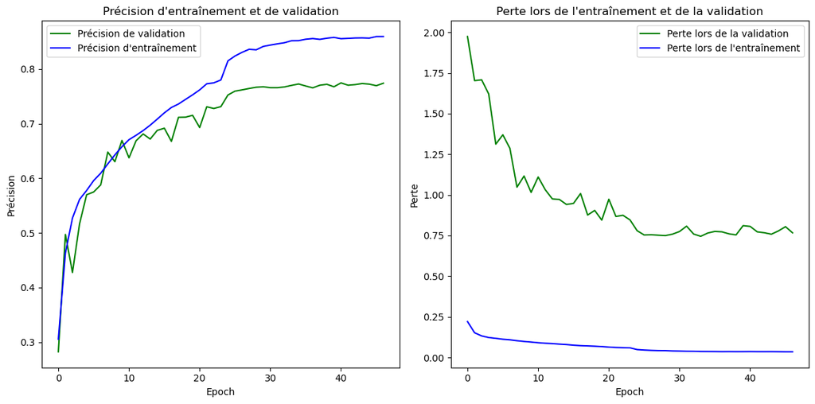

```
Précision du modèle sur l'ensemble de test: 91.08%
```

```python
def training_plot(history):
    plt.figure(figsize=(12, 6))

    plt.subplot(1, 2, 1)
    plt.plot(history.history['val_accuracy'], 'g', label="Précision de validation")
    plt.plot(history.history['accuracy'], 'b', label="Précision d'entraînement")
    plt.title("Précision d'entraînement et de validation")
    plt.xlabel("Epoch")
    plt.ylabel("Précision")
    plt.legend()

    plt.subplot(1, 2, 2)
    plt.plot(history.history['val_loss'], 'g', label="Perte lors de la validation")
    plt.plot(history.history['loss'], 'b', label="Perte lors de l'entraînement")
    plt.title("Perte lors de l'entraînement et de la validation")
    plt.xlabel("Epoch")
    plt.ylabel("Perte")
    plt.legend()

    plt.tight_layout()
    plt.show()

training_plot(history)

test_score = model.evaluate(training_gen)
accuracy = test_score[1] * 100
print(f"Précision du modèle sur l'ensemble de test: {accuracy:.2f}%")
```

En observant les courbes, on peut en déduire plusieurs informations.

- Précision : Si la précision de validation augmente et se rapproche de la précision d'entraînement, cela indique que le modèle généralise bien et est capable de bien classer de nouvelles données. Si la précision de validation reste faible par rapport à la précision d'entraînement, cela peut indiquer un problème de surapprentissage (overfitting) du modèle.
- Perte : Si la perte d'entraînement diminue progressivement et que la perte de validation diminue également, cela suggère que le modèle apprend efficacement et parvient à généraliser correctement. Si la perte d'entraînement diminue rapidement tandis que la perte de validation augmente, cela peut indiquer un surapprentissage.

En résumé, le modèle semble avoir une performance satisfaisante avec une précision en augmentation et des pertes en diminution. Cependant, pour obtenir de meilleures performances, il peut être nécessaire d'explorer des ajustements supplémentaires.

## Résultat à soumettre

```python
X_test = np.load('/kaggle/input/navires-2023-la-mano/test.npy', allow_pickle=True)
X_test = X_test.astype('float32') / 255
```

```python
X_test.shape, X_test.dtype
```

```
((3698, 16, 24, 3), dtype('float32'))
```

```python
res = model.predict(X_test).argmax(axis=1)
df = pd.DataFrame({"Category":res})
df.to_csv("submission.csv", index_label="Id")
```

```python
!head submission.csv
```

```
Id,Category
0,5
1,9
2,2
3,7
4,3
5,0
6,3
7,3
8,5
```

```python
import os
os.chdir(r'/kaggle/working')
from IPython.display import FileLink
FileLink(r'submission.csv')
```

submission.csv

```python
!rm -rf ships32/
```